# Super_Market_Sales

```python
# import all packages and set plots to be embedded inline
import numpy as np
import pandas as pd
import matplotlib.pyplot as plt
import seaborn as sb

%matplotlib inline
```

## Data Loading and Assesing

```python
# load in the dataset into a pandas dataframe, print first 5 rows
super_market = pd.read_csv('supermarket_sales.csv')
super_market.head()
```

|  | Invoice ID | Branch | City | Customer type | Gender | Product line | Unit price | Quantity | Tax 5% | Total | Date | Time | Payment | cogs | gross margin percentage | gross income | Rating |
| --- | --- | --- | --- | --- | --- | --- | --- | --- | --- | --- | --- | --- | --- | --- | --- | --- | --- |
| 0 | 750-67-8428 | A | Yangon | Member | Female | Health and beauty | 74.69 | 7 | 26.1415 | 548.9715 | 1/5/2019 | 13:08 | Ewallet | 522.83 | 4.761905 | 26.1415 | 9.1 |
| 1 | 226-31-3081 | C | Naypyitaw | Normal | Female | Electronic accessories | 15.28 | 5 | 3.8200 | 80.2200 | 3/8/2019 | 10:29 | Cash | 76.40 | 4.761905 | 3.8200 | 9.6 |
| 2 | 631-41-3108 | A | Yangon | Normal | Male | Home and lifestyle | 46.33 | 7 | 16.2155 | 340.5255 | 3/3/2019 | 13:23 | Credit card | 324.31 | 4.761905 | 16.2155 | 7.4 |
| 3 | 123-19-1176 | A | Yangon | Member | Male | Health and beauty | 58.22 | 8 | 23.2880 | 489.0480 | 1/27/2019 | 20:33 | Ewallet | 465.76 | 4.761905 | 23.2880 | 8.4 |
| 4 | 373-73-7910 | A | Yangon | Normal | Male | Sports and travel | 86.31 | 7 | 30.2085 | 634.3785 | 2/8/2019 | 10:37 | Ewallet | 604.17 | 4.761905 | 30.2085 | 5.3 |

```python
# high-level overview of data shape and composition
print(super_market.info())
print(super_market.shape)
print(super_market.dtypes)
```

```
<class 'pandas.core.frame.DataFrame'>
RangeIndex: 1000 entries, 0 to 999
Data columns (total 17 columns):
 #   Column                   Non-Null Count  Dtype
---  ------                   --------------  -----
 0   Invoice ID               1000 non-null   object
 1   Branch                   1000 non-null   object
 2   City                     1000 non-null   object
 3   Customer type            1000 non-null   object
 4   Gender                   1000 non-null   object
 5   Product line             1000 non-null   object
 6   Unit price               1000 non-null   float64
 7   Quantity                 1000 non-null   int64
 8   Tax 5%                   1000 non-null   float64
 9   Total                    1000 non-null   float64
 10  Date                     1000 non-null   object
 11  Time                     1000 non-null   object
 12  Payment                  1000 non-null   object
 13  cogs                     1000 non-null   float64
 14  gross margin percentage  1000 non-null   float64
 15  gross income             1000 non-null   float64
 16  Rating                   1000 non-null   float64
dtypes: float64(7), int64(1), object(9)
memory usage: 132.9+ KB
None
(1000, 17)
Invoice ID                  object
Branch                      object
City                        object
Customer type               object
Gender                      object
Product line                object
Unit price                 float64
Quantity                     int64
Tax 5%                     float64
Total                      float64
Date                        object
Time                        object
Payment                     object
cogs                       float64
gross margin percentage    float64
gross income               float64
Rating                     float64
dtype: object
```

```python
# Check duplicates
super_market.duplicated().sum()
```

```
0
```

```python
#check nulls
super_market.isnull().sum()
```

```
Invoice ID                 0
Branch                     0
City                       0
Customer type              0
Gender                     0
Product line               0
Unit price                 0
Quantity                   0
Tax 5%                     0
Total                      0
Date                       0
Time                       0
Payment                    0
cogs                       0
gross margin percentage    0
gross income               0
Rating                     0
dtype: int64
```

```python
super_market['Payment'].value_counts()
```

```
Ewallet        345
Cash           344
Credit card    311
Name: Payment, dtype: int64
```

```python
super_market['Product line'].value_counts()
```

```
Fashion accessories       178
Food and beverages        174
Electronic accessories    170
Sports and travel         166
Home and lifestyle        160
Health and beauty         152
Name: Product line, dtype: int64
```

```python
super_market['City'].value_counts()
```

```
Yangon       340
Mandalay     332
Naypyitaw    328
Name: City, dtype: int64
```

```python
#Summary Statistics
super_market.describe()
```

|  | Unit price | Quantity | Tax 5% | Total | cogs | gross margin percentage | gross income | Rating |
| --- | --- | --- | --- | --- | --- | --- | --- | --- |
| count | 1000.000000 | 1000.000000 | 1000.000000 | 1000.000000 | 1000.00000 | 1.000000e+03 | 1000.000000 | 1000.00000 |
| mean | 55.672130 | 5.510000 | 15.379369 | 322.966749 | 307.58738 | 4.761905e+00 | 15.379369 | 6.97270 |
| std | 26.494628 | 2.923431 | 11.708825 | 245.885335 | 234.17651 | 6.131498e-14 | 11.708825 | 1.71858 |
| min | 10.080000 | 1.000000 | 0.508500 | 10.678500 | 10.17000 | 4.761905e+00 | 0.508500 | 4.00000 |
| 25% | 32.875000 | 3.000000 | 5.924875 | 124.422375 | 118.49750 | 4.761905e+00 | 5.924875 | 5.50000 |
| 50% | 55.230000 | 5.000000 | 12.088000 | 253.848000 | 241.76000 | 4.761905e+00 | 12.088000 | 7.00000 |
| 75% | 77.935000 | 8.000000 | 22.445250 | 471.350250 | 448.90500 | 4.761905e+00 | 22.445250 | 8.50000 |
| max | 99.960000 | 10.000000 | 49.650000 | 1042.650000 | 993.00000 | 4.761905e+00 | 49.650000 | 10.00000 |

## Quality issues

#### 1- The date and time are objectives.

#### 2- The time of purchase diveded to two columns: date and time in hours and seconeds.

#### 3- The columns: branch, city, customer type, gender, and product line are objectives.

## Tidiness issues

#### 1- There is no hour of day, day of week, month name columns.

## Data Cleaning

#### 1- Convert branch, city, customer type, gender, and product line columns to category type

```python
super_market['Branch'] = super_market['Branch'].astype('category')
super_market['City'] = super_market['City'].astype('category')
super_market['Customer type'] = super_market['Customer type'].astype('category')
super_market['Gender'] = super_market['Gender'].astype('category')
super_market['Product line'] = super_market['Product line'].astype('category')
```

#### 2- Merge date and time columns

```python
super_market["time"] = super_market["Date"] + " " + super_market["Time"]
```

#### 3- Convert time column to datetime type

```python
super_market['time'] = pd.to_datetime(super_market['time'])
```

#### 4- create columns for purchase date in yyyy-mm-dd format, purchase hour of the day, purchase of week

```python
super_market['purchase_time'] = super_market.time.dt.strftime('%Y-%m-%d')
super_market['hour_ofday'] = super_market.time.dt.strftime('%H')
super_market['day_ofweek'] = super_market.time.dt.strftime('%A')
super_market['month_name'] = super_market.time.dt.month_name()
```

#### 5- create category column for day type as weekend days or work days

```python
super_market['WEEKDAY'] = pd.to_datetime(super_market['time']).dt.dayofweek
super_market['day_type'] = 0
super_market.loc[super_market['WEEKDAY'].isin([5, 6]), 'day_type'] = 'weekend'  # 5 and 6 correspond to Sat and Sun
super_market.loc[super_market['WEEKDAY'].isin([0, 1, 2, 3, 4]), 'day_type'] = 'work_days'
super_market['day_type'] = super_market['day_type'].astype('category')
```

#### 6- Drop unused columns

```python
super_market.drop(['purchase_time', 'WEEKDAY'], axis=1, inplace=True)
```

#### 7- Create a column to count the the number of orders per city population

```python
# create a list of the conditions

conditions = [
    (super_market['City'] =='Yangon'),
    (super_market['City'] =='Mandalay'),
    (super_market['City'] =='Naypyitaw')
    ]

# create a list of the values we want to assign for each condition
values = [1/5.4, 1/1.5, 1/0.64]

# create a new column and use np.select to assign values to it using our lists as arguments
super_market['orders_per_pop'] = np.select(conditions, values)
```

#### 8- Create a column to calculate number of items of each order per city population

```python
conditions = [
    (super_market['City'] =='Yangon'),
    (super_market['City'] =='Mandalay'),
    (super_market['City'] =='Naypyitaw')
    ]

# create a list of the values we want to assign for each condition
values = [super_market['Quantity']/5.4, super_market['Quantity']/1.5, super_market['Quantity']/0.64]

# create a new column and use np.select to assign values to it using our lists as arguments
super_market['items_per_pop'] = np.select(conditions, values)
```

```python
super_market.head()
```

|  | Invoice ID | Branch | City | Customer type | Gender | Product line | Unit price | Quantity | Tax 5% | Total | ... | gross margin percentage | gross income | Rating | time | hour_ofday | day_ofweek | month_name | day_type | orders_per_pop | items_per_pop |
| --- | --- | --- | --- | --- | --- | --- | --- | --- | --- | --- | --- | --- | --- | --- | --- | --- | --- | --- | --- | --- | --- |
| 0 | 750-67-8428 | A | Yangon | Member | Female | Health and beauty | 74.69 | 7 | 26.1415 | 548.9715 | ... | 4.761905 | 26.1415 | 9.1 | 2019-01-05 13:08:00 | 13 | Saturday | January | weekend | 0.185185 | 1.296296 |
| 1 | 226-31-3081 | C | Naypyitaw | Normal | Female | Electronic accessories | 15.28 | 5 | 3.8200 | 80.2200 | ... | 4.761905 | 3.8200 | 9.6 | 2019-03-08 10:29:00 | 10 | Friday | March | work_days | 1.562500 | 7.812500 |
| 2 | 631-41-3108 | A | Yangon | Normal | Male | Home and lifestyle | 46.33 | 7 | 16.2155 | 340.5255 | ... | 4.761905 | 16.2155 | 7.4 | 2019-03-03 13:23:00 | 13 | Sunday | March | weekend | 0.185185 | 1.296296 |
| 3 | 123-19-1176 | A | Yangon | Member | Male | Health and beauty | 58.22 | 8 | 23.2880 | 489.0480 | ... | 4.761905 | 23.2880 | 8.4 | 2019-01-27 20:33:00 | 20 | Sunday | January | weekend | 0.185185 | 1.481481 |
| 4 | 373-73-7910 | A | Yangon | Normal | Male | Sports and travel | 86.31 | 7 | 30.2085 | 634.3785 | ... | 4.761905 | 30.2085 | 5.3 | 2019-02-08 10:37:00 | 10 | Friday | February | work_days | 0.185185 | 1.296296 |

5 rows × 24 columns

```python
print(super_market.info())
```

```
<class 'pandas.core.frame.DataFrame'>
RangeIndex: 1000 entries, 0 to 999
Data columns (total 24 columns):
 #   Column                   Non-Null Count  Dtype
---  ------                   --------------  -----
 0   Invoice ID               1000 non-null   object
 1   Branch                   1000 non-null   category
 2   City                     1000 non-null   category
 3   Customer type            1000 non-null   category
 4   Gender                   1000 non-null   category
 5   Product line             1000 non-null   category
 6   Unit price               1000 non-null   float64
 7   Quantity                 1000 non-null   int64
 8   Tax 5%                   1000 non-null   float64
 9   Total                    1000 non-null   float64
```

[output cut: 17 more lines]

# A- Univariate Exploration

### What is the distribution of the number of orders, number of sold items, and gross income per branch?

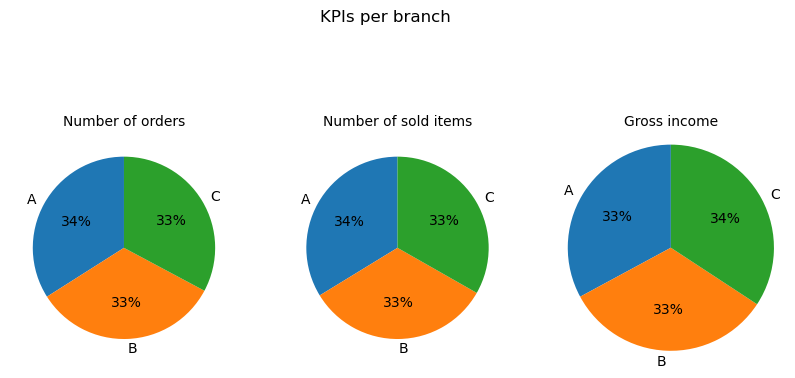

```python
plt.rcParams.update({'figure.figsize':(10,5), 'figure.dpi':100})
fig, (ax1, ax2, ax3) = plt.subplots(1, 3)
# Use the pie chart to describee the distribution of the number of orders for each branch
count = super_market.groupby('Branch')['Invoice ID'].count()
ax1.pie(count, labels = count.index, startangle = 90, autopct='%1.0f%%');
plt.axis('square');
ax1.set_title("Number of orders", fontsize= 10);

# Use the pie chart to describe the distribution of the number of orders for each branch
quantity_sum = super_market.groupby('Branch')['Quantity'].sum()
ax2.pie(quantity_sum, labels = quantity_sum.index, startangle = 90, autopct='%1.0f%%');
plt.axis('square');
ax2.set_title("Number of sold items", fontsize=10);

# Use the pie chart to describe the distribution of the gross income for each branch
gross_sum = super_market.groupby('Branch')['gross income'].sum()
ax3.pie(gross_sum, labels = gross_sum.index, startangle = 90, autopct='%1.0f%%');
plt.axis('square');
ax3.set_title("Gross income", fontsize=10);

plt.suptitle("KPIs per branch")
plt.show()
```

### What is the distribution of the number of orders, andnumber of sold items w.r.t the population of the city of each branch?

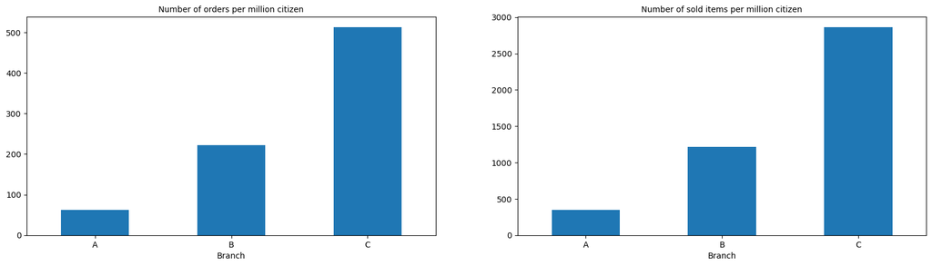

```python
plt.rcParams.update({'figure.figsize':(20,5), 'figure.dpi':100})
fig, (ax1, ax2) = plt.subplots(1, 2)

# Use the bar chart to describe the distribution of the number of purchases over months
order = ['A','B', 'C']
super_market.groupby('Branch')['orders_per_pop'].sum().loc[order].plot(kind='bar', ax=ax1)
ax1.set_title("Number of orders per million citizen", fontsize= 10);
ax1.set_xlabel('Branch', fontsize=10);
ax1.tick_params(axis='x', rotation=0)

# Use the bar chart to describe the distribution of the number of purchases over months
super_market.groupby('Branch')['items_per_pop'].sum().loc[order].plot(kind='bar', ax=ax2)
ax2.set_title("Number of sold items per million citizen", fontsize= 10);
ax2.set_xlabel('Branch', fontsize=10);
ax2.tick_params(axis='x', rotation=0)
```

### Comment:

#### Although the number of orders and summation of sold items are almost the same for all branches, but by taking the city's population of each branch, the Branch C in Naypyitaw city has the highest performance.

### What is the distribution of the number of orders, number of sold items, and gross income over months?

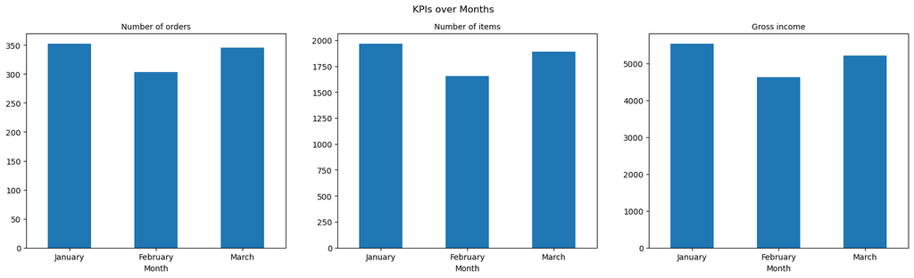

```python
plt.rcParams.update({'figure.figsize':(20,5), 'figure.dpi':100})
fig, (ax1, ax2, ax3) = plt.subplots(1, 3)

# Use the bar chart to describe the distribution of the number of purchases over months
order = ['January','February', 'March']
super_market.groupby('month_name')['Invoice ID'].count().loc[order].plot(kind='bar', ax=ax1)
ax1.set_title("Number of orders", fontsize= 10);
ax1.set_xlabel('Month', fontsize=10);
ax1.tick_params(axis='x', rotation=0)

# Use the bar chart to describe the distribution of the number of purchases over months
super_market.groupby('month_name')['Quantity'].sum().loc[order].plot(kind='bar', ax=ax2)
ax2.set_title("Number of items", fontsize= 10);
ax2.set_xlabel('Month', fontsize=10);
ax2.tick_params(axis='x', rotation=0)

# Use the bar chart to describe the distribution of the number of purchases over months
super_market.groupby('month_name')['gross income'].sum().loc[order].plot(kind='bar', ax=ax3)
ax3.set_title("Gross income", fontsize= 10);
ax3.set_xlabel('Month', fontsize=10);
ax3.tick_params(axis='x', rotation=0)

plt.suptitle("KPIs over Months")
plt.show()
```

### What is the distribution of the number of orders, number of sold items, and gross income over days of week?

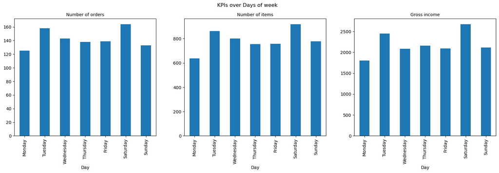

```python
plt.rcParams.update({'figure.figsize':(20,5), 'figure.dpi':100})
fig, (ax1, ax2, ax3) = plt.subplots(1, 3)

# Use the bar chart to describe the distribution of the number of purchases over day of week
orderd = ['Monday','Tuesday', 'Wednesday', 'Thursday', 'Friday', 'Saturday', 'Sunday']
super_market.groupby('day_ofweek')['Invoice ID'].count().loc[orderd].plot(kind='bar', ax=ax1)
ax1.set_title("Number of orders", fontsize= 10);
ax1.set_xlabel('Day', fontsize=10);

# Use the bar chart to describe the distribution of the number of purchases over day of week
super_market.groupby('day_ofweek')['Quantity'].sum().loc[orderd].plot(kind='bar', ax=ax2)
ax2.set_title("Number of items", fontsize= 10);
ax2.set_xlabel('Day', fontsize=10);

# Use the bar chart to describe the distribution of the number of purchases over day of week
super_market.groupby('day_ofweek')['gross income'].sum().loc[orderd].plot(kind='bar', ax=ax3)
ax3.set_title("Gross income", fontsize= 10);
ax3.set_xlabel('Day', fontsize=10);

plt.suptitle("KPIs over Days of week")
plt.show()
```

### What is the distribution of the number of orders, number of sold items, and gross income over hour of day?

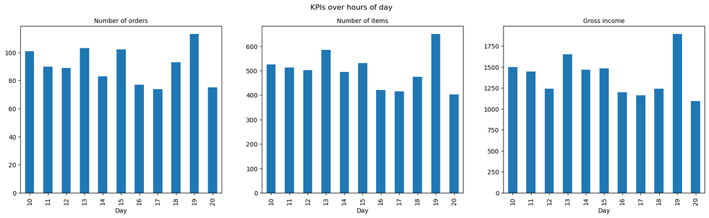

```python
plt.rcParams.update({'figure.figsize':(20,5), 'figure.dpi':100})
fig, (ax1, ax2, ax3) = plt.subplots(1, 3)

# Use the bar chart to describe the distribution of the number of purchases over day of week
orderd = ['10', '11', '12', '13', '14', '15', '16', '17', '18', '19', '20']
super_market.groupby('hour_ofday')['Invoice ID'].count().loc[orderd].plot(kind='bar', ax=ax1)
ax1.set_title("Number of orders", fontsize= 10);
ax1.set_xlabel('Day', fontsize=10);

# Use the bar chart to describe the distribution of the number of purchases over day of week
super_market.groupby('hour_ofday')['Quantity'].sum().loc[orderd].plot(kind='bar', ax=ax2)
ax2.set_title("Number of items", fontsize= 10);
ax2.set_xlabel('Day', fontsize=10);

# Use the bar chart to describe the distribution of the number of purchases over day of week
super_market.groupby('hour_ofday')['gross income'].sum().loc[orderd].plot(kind='bar', ax=ax3)
ax3.set_title("Gross income", fontsize= 10);
ax3.set_xlabel('Day', fontsize=10);

plt.suptitle("KPIs over hours of day")
plt.show()
```

### What is the distribution of the number of orders, number of sold items, and gross income per customer's type?

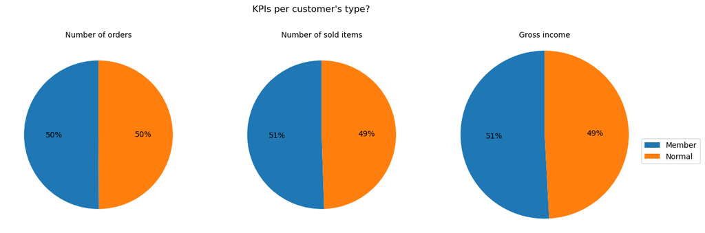

```python
plt.rcParams.update({'figure.figsize':(15,5), 'figure.dpi':100})
fig, (ax1, ax2, ax3) = plt.subplots(1, 3)
# Use the pie chart to describee the distribution of the number of orders for each branch
sorted_counts = super_market['Customer type'].value_counts()
ax1.pie(sorted_counts, startangle = 90, autopct='%1.0f%%');
plt.axis('square');
ax1.set_title("Number of orders", fontsize= 10);
plt.legend(labels = sorted_counts.index, bbox_to_anchor=(1,0.5), loc="upper left");

# Use the pie chart to describe the distribution of the number of orders for each branch
quantity_sum = super_market.groupby('Customer type')['Quantity'].sum()
ax2.pie(quantity_sum, startangle = 90, autopct='%1.0f%%');
plt.axis('square');
ax2.set_title("Number of sold items", fontsize=10);
plt.legend(labels = sorted_counts.index, bbox_to_anchor=(1,0.5), loc="upper left");

# Use the pie chart to describe the distribution of the gross income for each branch
gross_sum = super_market.groupby('Customer type')['gross income'].sum()
ax3.pie(gross_sum, startangle = 90, autopct='%1.0f%%');
plt.axis('square');
ax3.set_title("Gross income", fontsize=10);
plt.legend(labels = sorted_counts.index, bbox_to_anchor=(1,0.5), loc="upper left");

plt.suptitle("KPIs per customer's type?")
plt.show()
```

#### What is the distribution of the number of orders per day type?

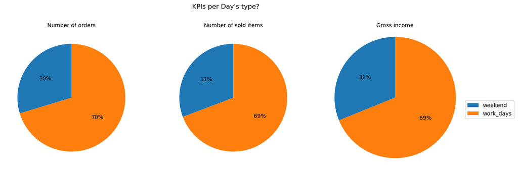

```python
plt.rcParams.update({'figure.figsize':(15,5), 'figure.dpi':100})
fig, (ax1, ax2, ax3) = plt.subplots(1, 3)

labels=['weekend', 'work_days']
# Use the pie chart to describee the distribution of the number of orders for each branch
ordersd = super_market.groupby('day_type')['Invoice ID'].count()
ax1.pie(ordersd, startangle = 90, autopct='%1.0f%%');
plt.axis('square');
ax1.set_title("Number of orders", fontsize= 10);
plt.legend(labels = labels, bbox_to_anchor=(1,0.5), loc="upper left");

# Use the pie chart to describe the distribution of the number of orders for each branch
labelss=['weekend', 'work_days']
quantity_sum = super_market.groupby('day_type')['Quantity'].sum()
ax2.pie(quantity_sum, startangle = 90, autopct='%1.0f%%');
plt.axis('square');
ax2.set_title("Number of sold items", fontsize=10);
plt.legend(labels = labelss, bbox_to_anchor=(1,0.5), loc="upper left");

# Use the pie chart to describe the distribution of the gross income for each branch
labelsss=['weekend', 'work_days']
gross_sum = super_market.groupby('day_type')['gross income'].sum()
ax3.pie(gross_sum, startangle = 90, autopct='%1.0f%%');
plt.axis('square');
ax3.set_title("Gross income", fontsize=10);
plt.legend(labels = labelsss, bbox_to_anchor=(1,0.5), loc="upper left");

plt.suptitle("KPIs per Day's type?")
plt.show()
```

### What is the distribution of the number of orders, number of sold items, and gross income per payment type?

[figure not shown]

```python
plt.rcParams.update({'figure.figsize':(15,5), 'figure.dpi':100})
fig, (ax1, ax2, ax3) = plt.subplots(1, 3)
# Use the pie chart to describee the distribution of the number of orders for each branch
counts = super_market.groupby('Payment')['Invoice ID'].count()
ax1.pie(counts, startangle = 90, autopct='%1.0f%%');
plt.axis('square');
ax1.set_title("Number of orders", fontsize= 10);
plt.legend(labels = sorted_counts.index, bbox_to_anchor=(1,0.5), loc="upper left");

# Use the pie chart to describe the distribution of the number of orders for each branch
quantity_sum = super_market.groupby('Payment')['Quantity'].sum()
ax2.pie(quantity_sum, startangle = 90, autopct='%1.0f%%');
plt.axis('square');
ax2.set_title("Number of sold items", fontsize=10);
plt.legend(labels = sorted_counts.index, bbox_to_anchor=(1,0.5), loc="upper left");

# Use the pie chart to describe the distribution of the gross income for each branch
gross_sum = super_market.groupby('Payment')['gross income'].sum()
ax3.pie(gross_sum, startangle = 90, autopct='%1.0f%%');
plt.axis('square');
ax3.set_title("Gross income", fontsize=10);
plt.legend(labels = sorted_counts.index, bbox_to_anchor=(1,0.5), loc="upper left");

plt.suptitle("KPIs per payment's type?")
plt.show()
```

### What is the distribution of the number of orders, number of sold items, and gross income for product lines?

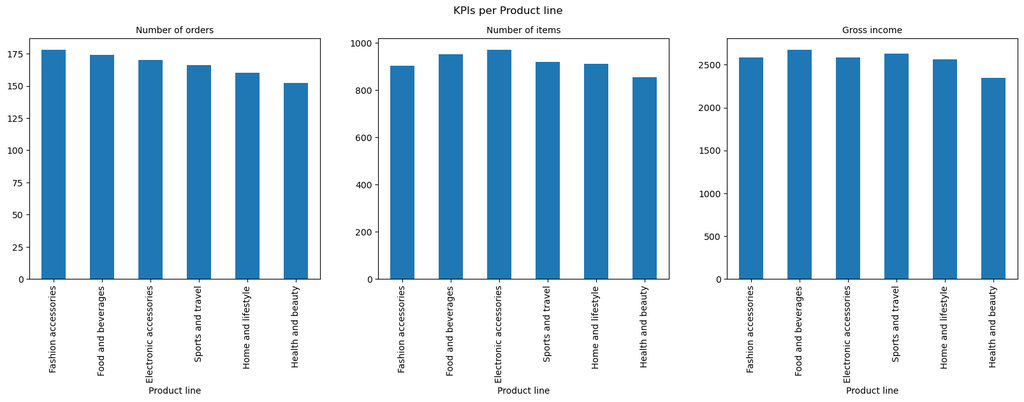

```python
plt.rcParams.update({'figure.figsize':(20,5), 'figure.dpi':100})
fig, (ax1, ax2, ax3) = plt.subplots(1, 3)

# Use the bar chart to describe the distribution of the number of purchases over day of week
orderd = super_market['Product line'].value_counts().index
super_market.groupby('Product line')['Invoice ID'].count().loc[orderd].plot(kind='bar', ax=ax1)
ax1.set_title("Number of orders", fontsize= 10);
ax1.set_xlabel('Product line', fontsize=10);

# Use the bar chart to describe the distribution of the number of purchases over day of week
super_market.groupby('Product line')['Quantity'].sum().loc[orderd].plot(kind='bar', ax=ax2)
ax2.set_title("Number of items", fontsize= 10);
ax2.set_xlabel('Product line', fontsize=10);

# Use the bar chart to describe the distribution of the number of purchases over day of week
super_market.groupby('Product line')['gross income'].sum().loc[orderd].plot(kind='bar', ax=ax3)
ax3.set_title("Gross income", fontsize= 10);
ax3.set_xlabel('Product line', fontsize=10);

plt.suptitle("KPIs per Product line")
plt.show()
```

### What is the distribution of the quantity of orders?

[figure not shown]

```python
plt.figure(figsize=[5, 4])
base_color = sb.color_palette()[0]
sb.distplot(super_market['Quantity'], kde=False, color=base_color);
plt.title("The Distribution of trips Duration", fontsize=20);
plt.xlabel('Number of sold items', fontsize=15);
plt.ylabel('Frequency', fontsize=15);
```

### What is the distribution of the custome's rating?

```python
#Creating bins for the customer's rating
super_market['rating_bins'] = super_market['Rating'].apply(lambda x: 'Very Bad' if 0<x<=2
                                                  else 'Bad' if 2<x<=4
                                                  else 'Moderate' if 4<x<=6
                                                  else 'Good' if 6<x<=8
                                                  else 'Very Good' if 8<x<=10
                                                  else x);
```

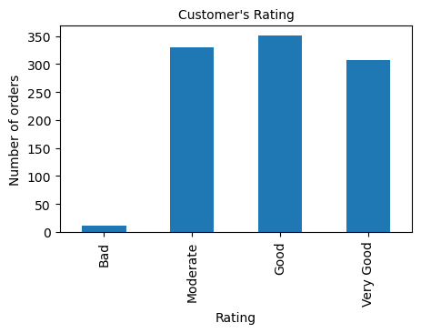

```python
plt.figure(figsize=[5, 3])
order = ['Bad', 'Moderate', 'Good', 'Very Good']
super_market.groupby('rating_bins')['Invoice ID'].count().loc[order].plot(kind = 'bar');
plt.title("Customer's Rating", fontsize=10);
plt.ylabel('Number of orders', fontsize=10);
plt.xlabel('Rating', fontsize=10);
```

```python
super_market.columns
```

```
Index(['Invoice ID', 'Branch', 'City', 'Customer type', 'Gender',
       'Product line', 'Unit price', 'Quantity', 'Tax 5%', 'Total', 'Date',
       'Time', 'Payment', 'cogs', 'gross margin percentage', 'gross income',
       'Rating', 'time', 'hour_ofday', 'day_ofweek', 'month_name', 'day_type',
       'orders_per_pop', 'items_per_pop', 'rating_bins'],
      dtype='object')
```

# B- Bivariate Exploration

#### In this section, I investigate relationships between pairs of variables in the data.

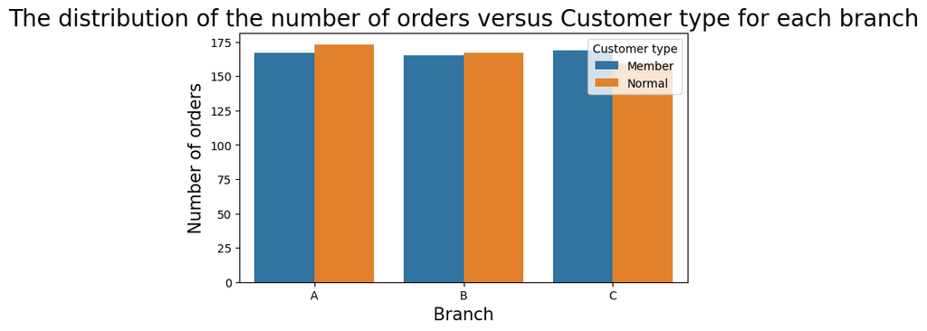

```python
plt.figure(figsize=[7, 4])
sb.countplot(data = super_market, x = 'Branch', hue = 'Customer type');
plt.title("The distribution of the number of orders versus Customer type for each branch", fontsize=20);
plt.xlabel('Branch', fontsize=15);
plt.ylabel('Number of orders', fontsize=15);
```

### Comment:

#### Branches A and B should make more efforts by making offers and bounses to acquire more members whose have loyality for the super market

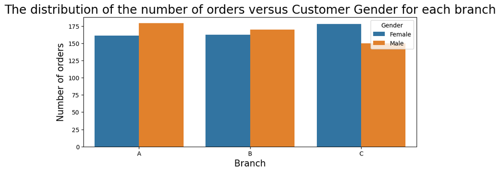

```python
plt.figure(figsize=[10, 4])
sb.countplot(data = super_market, x = 'Branch', hue = 'Gender');
plt.title("The distribution of the number of orders versus Customer Gender for each branch", fontsize=20);
plt.xlabel('Branch', fontsize=15);
plt.ylabel('Number of orders', fontsize=15);
```

### Comment:

#### The women treatment policies of branches A and B should be revised to attract more women whose manly purchase the goods of the family

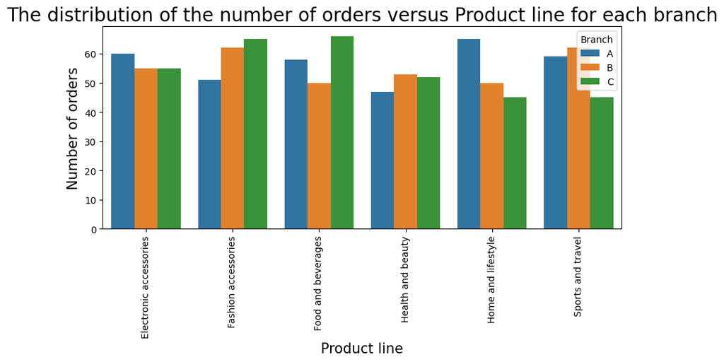

```python
plt.figure(figsize=[10, 4])
sb.countplot(data = super_market, x = 'Product line', hue = 'Branch');
plt.title("The distribution of the number of orders versus Product line for each branch", fontsize=20);
plt.xlabel('Product line', fontsize=15);
plt.ylabel('Number of orders', fontsize=15);
plt.tick_params(axis='x', rotation=90)
```

### Comment:

#### The three branches should increase the less purchase product lines by making attractive offers

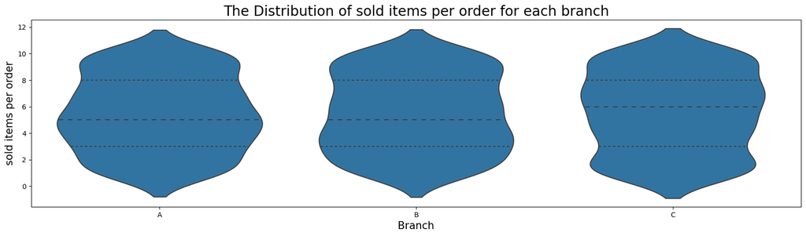

```python
sb.violinplot(data=super_market, x='Branch', y='Quantity', color=base_color, inner='quartile');
plt.title("The Distribution of sold items per order for each branch", fontsize=20);
plt.xlabel('Branch', fontsize=15);
plt.ylabel('sold items per order', fontsize=15);
```

### Comment:

#### Branch C has the highest median of number of sold items. Branches A and B must make attractive offers on the number of sold items ( e.g. 6 items with the same price of 5)

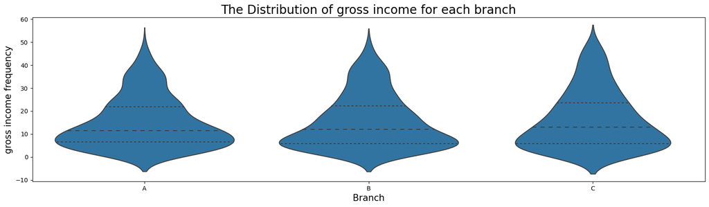

```python
sb.violinplot(data=super_market, x='Branch', y='gross income', color=base_color, inner='quartile');
plt.title("The Distribution of gross income for each branch", fontsize=20);
plt.xlabel('Branch', fontsize=15);
plt.ylabel('gross income frequency', fontsize=15);
```

### Comment:

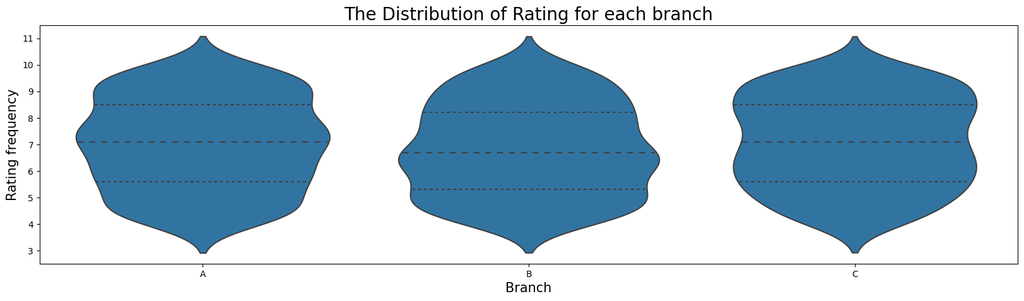

```python
sb.violinplot(data=super_market, x='Branch', y='Rating', color=base_color, inner='quartile');
plt.title("The Distribution of Rating for each branch", fontsize=20);
plt.xlabel('Branch', fontsize=15);
plt.ylabel('Rating frequency', fontsize=15);
```

### Comment:

#### branch C show slightly better performance with respect to the rating. While branch B has the worst performance

# B- Multivariate Exploration

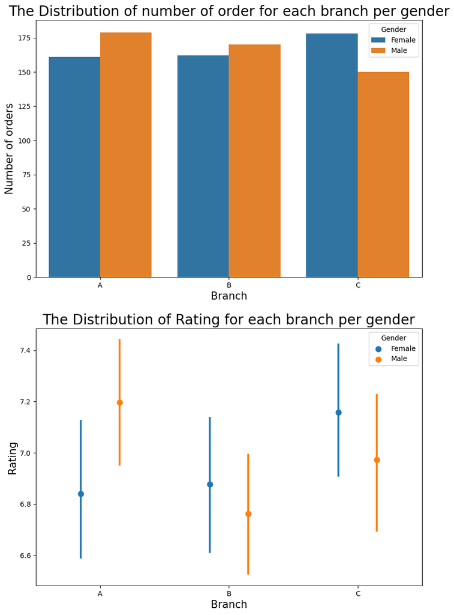

```python
plt.figure(figsize=[10, 15])

plt.subplot(2, 1, 1)
sb.countplot(data = super_market, x = 'Branch', hue = 'Gender');
plt.title("The Distribution of number of order for each branch per gender", fontsize=20);
plt.xlabel('Branch', fontsize=15);
plt.ylabel('Number of orders', fontsize=15);

# Use the clustered bar chart to describe the distribution of the trips average durations versus the day of week for each member gender
plt.subplot(2, 1, 2)
sb.pointplot(data = super_market, x = 'Branch', y='Rating', hue = 'Gender', dodge=0.3, linestyles="");
plt.title("The Distribution of Rating for each branch per gender", fontsize=20);
plt.xlabel('Branch', fontsize=15);
plt.ylabel('Rating', fontsize=15);
```

### Comment:

#### The big difference between men and women average rating beside the difference of number of orders says that branch A has a problem of dealing with purchases of women

[figure not shown]

```python
plt.figure(figsize=[15, 7])
branch_prductline = super_market.groupby(['Branch', 'Product line']).sum()['gross income']
branch_prductline = branch_prductline.reset_index(name = 'sum_gross_income')
branch_prductline = branch_prductline.pivot(index = 'Product line', columns = 'Branch',
                            values = 'sum_gross_income')
sb.heatmap(branch_prductline, annot = True, fmt = '.3f',
           cbar_kws = {'label' : 'gross income'});
plt.title('The summation of gross income for product lines per branch', fontsize=20)
plt.xlabel('Branchs', fontsize=15);
plt.ylabel('Product line', fontsize=15);
```

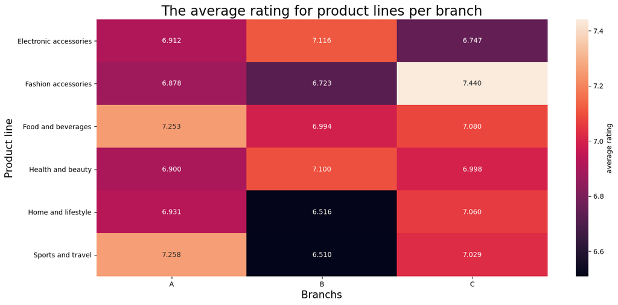

```python
plt.figure(figsize=[15, 7])
branch_prductline = super_market.groupby(['Branch', 'Product line']).mean()['Rating']
branch_prductline = branch_prductline.reset_index(name = 'average rating')
branch_prductline = branch_prductline.pivot(index = 'Product line', columns = 'Branch',
                            values = 'average rating')
sb.heatmap(branch_prductline, annot = True, fmt = '.3f',
           cbar_kws = {'label' : 'average rating'});
plt.title('The average rating for product lines per branch', fontsize=20)
plt.xlabel('Branchs', fontsize=15);
plt.ylabel('Product line', fontsize=15);
```

### Comment:

#### Branch A: Although home and life-style products aquire the highest gross income for the branch, the rating for this line is below average. humman resources department should train the employee of this line to gain the satisfaction of customers

#### Branch B: Home and life style and sports and travel lines achieve very goog gross income and have the worst rating levels !!. HR department shoud train the employees to gain the satisfaction of customers

#### Branch C: Although the most customers are wonen, the home and life-style line shows a bad gross income, so some offers and new products may increase the purchases of this line. Also, it have a good rating performance for all product lines.

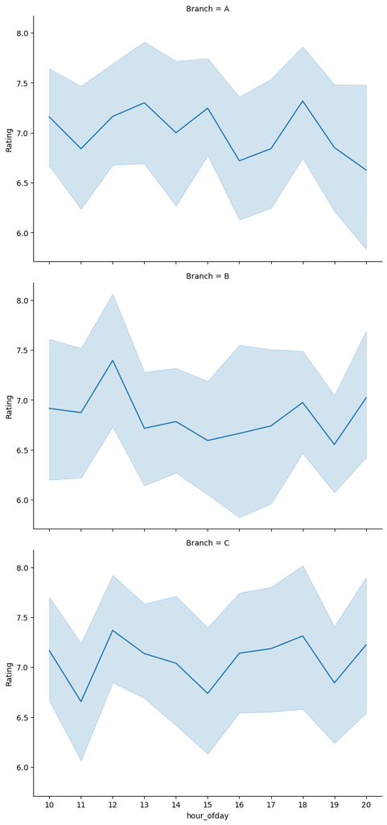

```python
plt.figure(figsize=[20, 7])
super_market['hour_ofday'] = pd.Categorical(super_market['hour_ofday'],
                                   categories=['10', '11', '12', '13', '14', '15', '16', '17', '18', '19', '20'],
                                   ordered=True)

rating_hourofday_branch  = sb.relplot(x="hour_ofday",  y = 'Rating', row= 'Branch', kind="line", height=5, aspect=7/5, data =super_market)
```

### Comment:

#### The HR department should be focused on employes whose have work shift when the ratings are vey low to increase their skills to get higher satisfaction of customers